# Aside

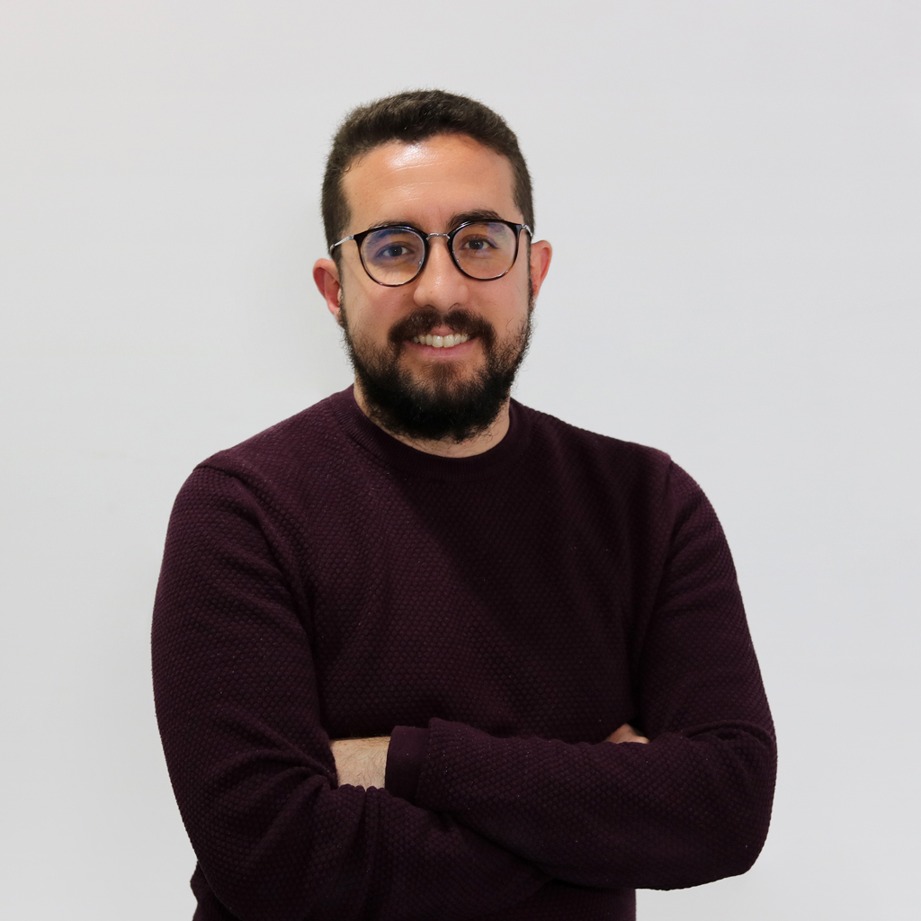

## Contacto

- antoniogmzgallego@gmail.com
- [Linkedin](https://www.linkedin.com/in/antoniog%C3%B3mezgallego/)
- +34 691078295

## Capacidades

- Lenguajes de programación (Python, R y JavaScript)
- Web (HTML, CSS, Shiny, Django y Vue.js)
- Bases de Datos (SQL y NoSQL)
- Control de versiones (Git)
- Contenedores Docker
- Idiomas (Inglés, B1)

# Main

## Experiencia profesional

### Software Developer

Alten - Wonnai

España

Actualidad - Diciembre 2023

- Integración de APIs con terceros
- Desarrollo de backend para el sector seguros

### Software Developer

reclamador.es

España

Diciembre 2023 - Octubre 2022

- Romper monolito y extracción de sistema de facturación (ERP Navision) en un microservicio.
- Integración de monolito con nuevo microservicio (FastApi).
- Mantenimiento y adición de nuevas features en el monolito en otros módulos del negocio (Django).
- Integración con otros servicios de terceros como API del tiempo

### Software Developer

BeSoccer.

Málaga, España

Octubre 2022 - Marzo 2022

- Desarrollo de API REST con Flask en Python.
- Web Scraping con diferentes librerías de Python. BeautifulSoup y Selenium.
- Desarrollo de proceso ETL para extracción de información de diferentes web, transformación a formato correcto e inserción en base de datos.
- Consulta en base de datos SQL para posterior análisis.
- Uso de librería pytest para realización de test en el proceso de despliegue de API mediante CD/CI. Uso de docker.
- Desarrollo de Front que permite interactuar con API REST y visualización de resultados.

### Data Scientist - Shiny Developer

Grupo Petroprix & Hello Auto.

Jaén, España

Junio 2023 - Marzo 2021

- Extracción de información en BBDD SQL y NoSQL.
- Procesamiento de datos para presentación en Dashboard realizados con Shiny.
- Dockerizacion de aplicaciones y despliegue.
- Automatización de script en Python para consulta de APIs.
- Realización de modelos de machine learning para predecir la potencia y valoración del vehículo en función de los últimos dígitos del número de bastidor.
- Realización de modelos de Pricing de Seguros de Coche.
- Jornada pacial desde marzo de 2022

### Junior Data Scientist - Shiny Developer

Quental Technologies - Banco Santander.

Madrid, España

Marzo 2021 - Diciembre 2019

- Desarrollo de aplicaciones web orientadas al análisis de datos con librería Shiny de R, HTML5, CSS3 y JavaScript y despliegue en contenedores docker.
- Aplicación de técnicas de limpieza de datos.
- Ejecución de modelos de fuga de clientes y detección de fraude.
- Desarrollo backend de cálculo de métricas para proyecto de riesgos en R.

### Becario

Banco Santander.

Madrid, España

Diciembre 2019 - Junio 2019

- Tratamiento y consolidación de bases de datos con Excel.
- Automatización de script en R para limpieza de bases de datos.

### Beca de colaboración en Departamento de Estadística e Investigación Operativa

Universidad de Jaén.

Jaén, España

Junio 2019 - Octubre 2018

- Utilización de bases de datos públicas para proponer publicaciones en forma de noticia breve en la prensa provincial.
- Todo el tratamiento se realizará en el software estadístico R y librería ggplot2.

### Proyecto de Innovación Docente en Departamento de Estadística e Investigación Operativa.

Universidad de Jaén.

Jaén, España

Mayo 2019 - Mayo 2018

- Desarrollo de app en Shiny, HTML5, CSS3 y JavaScript para la asignatura de Estadística I del grado de ADE+Derecho.

## Formación

### Universidad Complutense de Madrid

Máster en Tratamiento Estadístico-Computacional  
de la Información (Pendiente finalizar)

Madrid, España

2019

TFM: Desarrollo de OCR en Python para la lectura automática de albaranes de transporte para la Empresa Trucksters.

### Universidad de Jaén

Grado en Estadística y Empresa

Jaén, España

2019 - 2015

TFG: Análisis de datos mediante Regresión de Poisson. Más concretamente se estudia el modelo de regresión de Poisson y se aplica a este modelo tratando explicar el comportamiento que tienen el número de bares, restaurantes y cafeterías en los municipios de la provincia de Jaén en función de otras covariables.

Premio Extraordinario Mejor Expediente de Promoción